# Régression linéaire

Prédiction du prix d'un vin

*Objectifs* :

Ce Projet a pour but de mettre en oeuvre les méthodes relatives à la régression linéaire étudiées en cours afin de prédire la qualité d'un vin. Plus particulièrement :

- Identifier les variables explicatives pertinentes.
- Identifier les dépendance non-linéaires entre réponse et prédicteurs.
- Identifier les interactions entre prédicteurs.
- Evaluer la qualité du modèle linéaire.
- Faire des prédictions à partir du modèle linéaire.

Dans cette séance, les librairies suivantes seront utilisées : installez-les si nécessaire et chargez-les

```python
import pandas as pd
import numpy as np
import seaborn as sns
from matplotlib import pyplot as plt
from mpl_toolkits.mplot3d import axes3d
from sklearn.linear_model import LinearRegression
from sklearn.metrics import r2_score
```

## Table des matières

1 - Résultats théoriques

2 - Introduction : présentation du jeu de données et analyse préliminaire

3 - Régression linéaire simple

4 - Régression linéaire multivariée

5 - Recherche de colinéarité

6 - Terme d'interaction

7 - Représentation diagnostic et importance des variables prédictives

8 - Nouvelles prédictions

Annexe

## 1 Résultats théoriques

On considère la régression linéaire simple :

$$y_i=\beta_0 + \beta_1 x_i $$

pour $n$ observations $(x_i,y_i)$.

1. Montrer que

$$\hat{\beta}_1=\frac{\sigma_{XY}}{\sigma_{X}^2}~~~~~~~~~~~~~(\clubsuit)$$$$\text{et}$$$$\hat{\beta_0}=\bar{y} - \hat{\beta_1} \bar{x}~~~~~~~~~~(\spadesuit) $$

avec $$\bar{x}=\frac{1}{n}\sum_{i=1}^n x_i $$ $$\bar{y}=\frac{1}{n}\sum_{i=1}^n y_i $$ $$\sigma_{XY}=\frac{1}{n}\sum_{i=1}^n (x_i - \bar{x}) (y_i - \bar{y}) \text{ (covariance entre $X$ et $Y$)}$$ $$\sigma_{X}^2=\frac{1}{n}\sum_{i=1}^n (x_i - \bar{x})^2 \text{ (variance de $X$)}$$

2. Montrer que

$$R^2=\frac{\sigma_{XY}^2}{\sigma_{X}^2\sigma_{Y}^2} $$

où $$\sigma_{Y}^2=\frac{1}{n}\sum_{i=1}^n (y_i - \bar{y})^2 $$

## 2 Introduction : présentation du jeu de données et analyse préliminaire

Ce problème reprend des données et un modèle ayant donné lieu à une intense polémique : en mars 1990, Orley Ashenfelter, un professeur d’économie de Princeton publie un article affirmant que l’on peut prédire la qualité du vin, et son prix, sans même le goûter, à partir d’une formule mathématique. Scandale chez les experts de l’œnologie : “Ashenfelter is an absolute total sham” ou “rather like a movie critic who never goes to see the movie but tells you how good it is based on the actors and the director”. Dans les faits, la “Bordeaux-formula” donne des résultats intéressants qui parfois dépassent les prévisions des experts. L’approche analytique est maintenant lentement adoptée par la communauté.

Ces données proviennent du site de [Ashenfelter, Liquid Assets](http://liquidasset.com/). Elles comprennent $25$ observations et $7$ variables.

| Nom | Description |
| --- | --- |
| Year | Année de production du vin |
| Price | prix de vente (une approximation de la qualité du vin) en 1990 |
| WinterRain | Précipitations pendant l’hiver |
| AGST | Average Growing Season Temperature |
|  | Température moyenne pendant la croissance |
| HarvestRain | Précipitations pendant l'été |
| Age | âge du vin (en général les vins les plus anciens sont plus chers) |
| FrancePop | Population française |

La variable dépendante est 'Price'.

Les variables indépendantes sont 'Year', 'WinterRain', 'AGST', 'HarvestRain', 'Age', 'FrancePop'.

> Tâche 1. Chargeons les données. Examinons quelles sont les caractéristiques des variables du jeu de données.

```python
data=pd.read_csv("wine.csv")
```

```python
data.shape
```

```
(25, 7)
```

```python
data.head()
```

|  | Year | Price | WinterRain | AGST | HarvestRain | Age | FrancePop |
| --- | --- | --- | --- | --- | --- | --- | --- |
| 0 | 1952 | 7.4950 | 600 | 17.1167 | 160 | 31 | 43183.569 |
| 1 | 1953 | 8.0393 | 690 | 16.7333 | 80 | 30 | 43495.030 |
| 2 | 1955 | 7.6858 | 502 | 17.1500 | 130 | 28 | 44217.857 |
| 3 | 1957 | 6.9845 | 420 | 16.1333 | 110 | 26 | 45152.252 |
| 4 | 1958 | 6.7772 | 582 | 16.4167 | 187 | 25 | 45653.805 |

```python
data.info()
```

```
<class 'pandas.core.frame.DataFrame'>
RangeIndex: 25 entries, 0 to 24
Data columns (total 7 columns):
 #   Column       Non-Null Count  Dtype
---  ------       --------------  -----
 0   Year         25 non-null     int64
 1   Price        25 non-null     float64
 2   WinterRain   25 non-null     int64
 3   AGST         25 non-null     float64
 4   HarvestRain  25 non-null     int64
 5   Age          25 non-null     int64
 6   FrancePop    25 non-null     float64
dtypes: float64(3), int64(4)
memory usage: 1.5 KB
```

```python
data.describe()
```

|  | Year | Price | WinterRain | AGST | HarvestRain | Age | FrancePop |
| --- | --- | --- | --- | --- | --- | --- | --- |
| count | 25.000000 | 25.000000 | 25.000000 | 25.000000 | 25.000000 | 25.000000 | 25.000000 |
| mean | 1965.800000 | 7.067224 | 605.280000 | 16.509336 | 148.560000 | 17.200000 | 49694.436760 |
| std | 7.691987 | 0.650341 | 132.277965 | 0.675397 | 74.419464 | 7.691987 | 3665.270243 |
| min | 1952.000000 | 6.204900 | 376.000000 | 14.983300 | 38.000000 | 5.000000 | 43183.569000 |
| 25% | 1960.000000 | 6.518800 | 536.000000 | 16.200000 | 89.000000 | 11.000000 | 46583.995000 |
| 50% | 1966.000000 | 7.121100 | 600.000000 | 16.533300 | 130.000000 | 17.000000 | 50254.966000 |
| 75% | 1972.000000 | 7.495000 | 697.000000 | 17.066700 | 187.000000 | 23.000000 | 52894.183000 |
| max | 1978.000000 | 8.493700 | 830.000000 | 17.650000 | 292.000000 | 31.000000 | 54602.193000 |

```python
data.isna().sum().sum()
```

```
0
```

```python
data['FrancePop'].values
```

```
array([43183.569, 43495.03 , 44217.857, 45152.252, 45653.805, 46128.638,
       46583.995, 47128.005, 48088.673, 48798.99 , 49356.943, 49801.821,
       50254.966, 50650.406, 51034.413, 51470.276, 51918.389, 52431.647,
       52894.183, 53332.805, 53689.61 , 53955.042, 54159.049, 54378.362,
       54602.193])
```

> Commentaires. On remarque qu'il n'y a pas de données manquantes. La variable 'FrancePop' est mal formatée (à multiplier par un facteur $10^3$ pour avoir les bons ordres de grandeur).

> Tâche 2. Regardez la corrélation entre :
> - 'AGST' et 'PRICE' d'une part et entre 'AGST' et log('PRICE') d'autre part,
> - 'HarvestRain' et 'PRICE' d'une part et entre 'HarvestRain' et log('PRICE') d'autre part.

> A l'aide de la fonction skew, regardez le coefficent d'asymétrie de 'Price'.

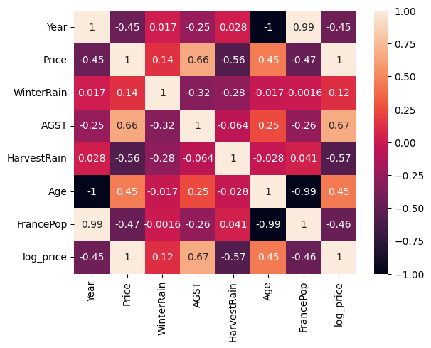

```python
data['log_price']=np.log(data['Price'])
corr = data.corr()
sns.heatmap(corr, vmin=-1, vmax=1,annot=True)
```

```python
print(data['Price'].skew())
print(data['log_price'].skew())
```

```
0.369119560072439
0.218120506356655
```

Dans la suite, nous utiliserons donc la transformation logarithmique de la variable à prédire.

> Tâche 3. Traçons le logarithme du prix de vente en fonction de

'AGST' d'une part puis de 'HarvestRain'.

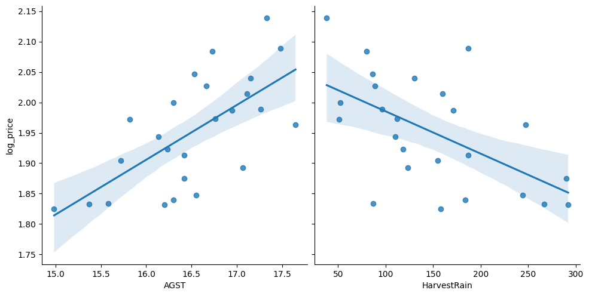

```python
sns.pairplot(data, x_vars=["AGST","HarvestRain"], y_vars=["log_price"],height=5, aspect=1, kind="reg");
```

Retour à la table des matières

## 3 Régression linéaire simple

> Effectuons une première régression model1 du (logarithme du) prix en fonction de AGST. Utiliser pour cela la fonction LinearRegressor se trouvant dans sklearn.linear_model.

> Calculons le RSS pour ce modèle et comparez le au RSS du modèle baseline (il s'agit alors du TSS).

> Déduisons-en le $R^2$ du modèle, et comparons

le à celui qui est fourni par la fonction r2_score qui se trouve dans sklearn.metrics.

> Calculons le residual standard eror (RSE) des deux modèles.

```python
y=data['log_price']
```

```python
#Modèle baseline
y_pred_baseline=y.mean()
TSS=sum( (y-y_pred_baseline)**2)
print(TSS)
```

```
0.19964647667257596
```

```python
#Modèle 1
regr_simple=LinearRegression()
X_simple=data[['AGST']]
regr_simple.fit(X_simple,y)
print(regr_simple.coef_)
print(regr_simple.intercept_)
y_pred_simple=regr_simple.predict(X_simple)
RSS_simple=sum( (y-y_pred_simple)**2)
print(RSS_simple)
```

```
[0.08995136]
0.46641576624792114
0.11106462827059728
```

```python
R2=1-RSS_simple/TSS
print(R2)
```

```
0.44369352206127133
```

```python
R2_autre=r2_score(y,y_pred_simple)
print(R2_autre)
```

```
0.44369352206127133
```

```python
n=25
p=1
```

```python
RSE_baseline=np.sqrt( sum((y-y_pred_baseline)**2)/(n-p-1))
print(RSE_baseline/np.mean(y))
print(RSE_baseline)
```

```
0.04774290210594527
0.09316802882137104
```

```python
RSE_simple=np.sqrt( sum((y-y_pred_simple)**2)/(n-p-1))
print(RSE_simple/np.mean(y))
print(RSE_simple)
```

```
0.03560949978808607
0.06949026465146263
```

Retour à la table des matières

## 4 Régression linéaire multivariée

> Tâche 5. Ajoutons la nouvelle variable indépendante 'HarvestRain' pour un nouveau modèle model2. Considérons la nouvelle valeur du $R^2$ : le modèle est-il amélioré, cette variable est-elle significative ? Donnons à nouveau la valeur du RSE.

```python
#Modèle 2
p=2
regr_2=LinearRegression()
X_2=data[['AGST','HarvestRain']]
regr_2.fit(X_2,y)
y_pred_2=regr_2.predict(X_2)
R2_2=r2_score(y,y_pred_2)
print(R2_2)
RSE_2=np.sqrt( sum((y-y_pred_2)**2)/(n-p-1))
print(RSE_2)
```

```
0.7202985226007073
0.050381009446599165
```

> Tâche 6. Construisons maintenant un modèle avec l'ensemble des variables disponibles. Donnons le $R^2$ et le RSE correspondants.

```python
list_noms=data.columns.drop('Price','log_price')
print(list_noms)
```

```
Index(['Year', 'WinterRain', 'AGST', 'HarvestRain', 'Age', 'FrancePop',
       'log_price'],
      dtype='object')
```

```python
#Modèle 3
p=6
regr_tot=LinearRegression()
X_tot=data[['Year', 'WinterRain', 'AGST', 'HarvestRain', 'Age', 'FrancePop']]
regr_tot.fit(X_tot,y)
y_pred_tot=regr_tot.predict(X_tot)
R2_tot=r2_score(y,y_pred_tot)
print(R2_tot)
RSE_tot=np.sqrt( sum((y-y_pred_tot)**2)/(n-p-1))
print(RSE_tot)
```

```
0.8336335773061083
0.0429563539003745
```

Retour à la table des matières

## 5 Recherche de colinéarité

> Tâche 7. Les colinarités peuvent impacter négativement les performances du modèle. Repérons-les à l'aide des coefficients de corrélations, des nuages de points et par le raisonnement. Créons un nouveau modèle linéaire sans colinéarité.

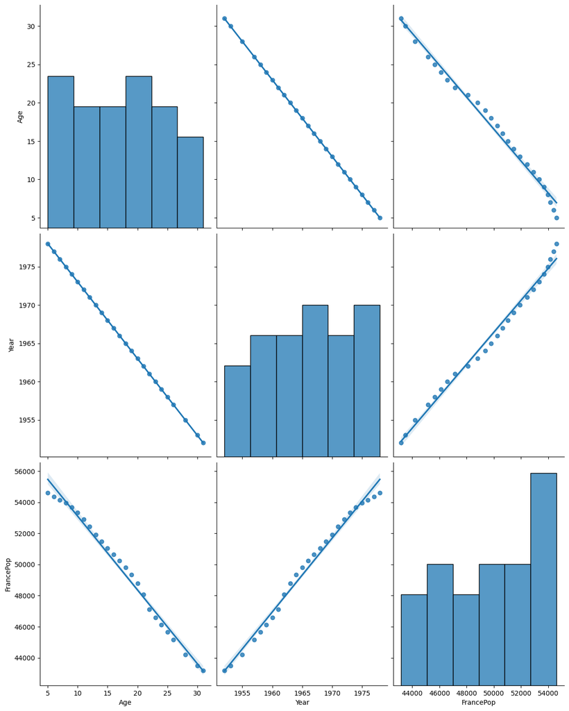

```python
#on a déjà les corrélations
#on trace les nuages de points
sns.pairplot(data[['Age','Year','FrancePop']],height=5, aspect=.8, kind="reg");
```

> Commentaire. La corrélation ainsi que les nuages de points nous montre que ces variables sont fortement colinéaires. C'était également attendu.

> On ne garde que l'année pour le modèle linéaire.

```python
#Modèle 4
p=4
regr_col=LinearRegression()
X_col=data[['Year', 'WinterRain', 'AGST', 'HarvestRain']]
regr_col.fit(X_col,y)
y_pred_col=regr_col.predict(X_col)
R2_col=r2_score(y,y_pred_col)
print(R2_col)
RSE_col=np.sqrt( sum((y-y_pred_col)**2)/(n-p-1))
print(RSE_col)
```

```
0.8328052014802982
0.04085330613453436
```

> Commentaire. L'algorithme de régression linéaire de LinearRegression() est robuste aux multicolinéarités.

Retour à la table des matières

## 6 Terme d'interaction

> Tâche 8. Il est raisonnable de penser que la qualité d'un vin, est donc son prix, peut ếtre impactée par les précipitations hivernales et estivales conjointement. Ajouter au jeu de données la variable 'WinterRain_HarvestRain', produit des variables 'WinterRain' et 'HarvestRain'. Créons le modèle linéaire incluant les variables précédemment sélectionnées et la nouvelle variable d'interaction. Le RSE et le $R^2$ en sont-ils améliorés ?

```python
data['WinterRain_HarvestRain']=data['WinterRain']*data['HarvestRain']
```

```python
regr_col=LinearRegression()
p=5
X_col=data[['Year', 'WinterRain', 'AGST', 'HarvestRain','WinterRain_HarvestRain']]
regr_col.fit(X_col,y)
y_pred_col=regr_col.predict(X_col)
R2_col=r2_score(y,y_pred_col)
print(R2_col)
RSE_col=np.sqrt( sum((y-y_pred_col)**2)/(n-p-1))
print(RSE_col)
```

```
0.8556597745783114
0.03894464184992894
```

> Commentaire. Le modèle est meilleur.

Retour à la table des matières

## 7 Représentation diagnostic et importance des variables prédictives

> Tâche 9 : test de l'hypothèse d'homoscédasticité. Traçons le *residual plot*, c'est-à-dire les résidus obtenus en fonction des valeurs prédites (*fitted*) et conclurons quant à l'homoscédasticité du modèle.

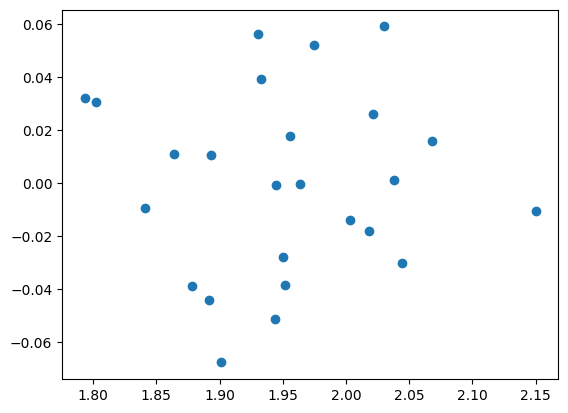

```python
res=(y-y_pred_col)
plt.scatter(y_pred_col, res)
```

> Commentaire. Le residual plot n'a pas de tendance particulière : l'hypothèse d'homoscédasticité est vérifée.

> Tâche 10. Affichons l'estimation de l'intercept et des coefficients du modèle linéaire. Peut-on affirmer que 'AGST' est un facteur plus important que 'Year' ?

```python
print(regr_col.intercept_)
print(regr_col.coef_)
```

```
8.576634735714348
[-4.09803999e-03  3.55965226e-04  7.78237300e-02  6.19843869e-04
 -1.85089666e-06]
```

> On ne peut donc pas affirmer que 'AGST' est un facteur plus important que 'Year'.

Retour à la table des matières

## 8 Nouvelles prédictions

> Tâche 11. Il s'agit enfin de prédire le prix de vente pour les années 1979 et 1980. Ces données sont

fournies dans le fichier wine_test.csv. Effectuons la prédiction. Comparons ces deux résultats aux valeurs exactes.

```python
test=pd.read_csv('wine_test.csv')
test
```

|  | Year | Price | WinterRain | AGST | HarvestRain | Age | FrancePop |
| --- | --- | --- | --- | --- | --- | --- | --- |
| 0 | 1979 | 6.9541 | 717 | 16.1667 | 122 | 4 | 54835.832 |
| 1 | 1980 | 6.4979 | 578 | 16.0000 | 74 | 3 | 55110.236 |

```python
test['WinterRain_HarvestRain']=test['WinterRain']*test['HarvestRain']
```

```python
price_test=regr_col.predict(test[['Year', 'WinterRain', 'AGST', 'HarvestRain','WinterRain_HarvestRain']])
```

```python
print(price_test)
print(np.exp(price_test))
print(test['Price'])
print(sum((test['Price']-np.exp(price_test))**2))
```

```
[1.89370918 1.88014503]
[6.64396668 6.5544554 ]
0    6.9541
1    6.4979
Name: Price, dtype: float64
0.09938118790982556
```

```python
R2=r2_score(np.log(test['Price']),price_test)
print(R2)
```

```
0.06319974091316427
```

Retour à la table des matières

## Annexe

Il existe d'autre librairies de régression linéaire en python, avec des méthodes statistiques plus riches.

```python
import statsmodels.api as sm
```

```python
mod = sm.OLS(y, X_col)
res = mod.fit()
print(res.summary())
print(res.conf_int(0.05))   # 95% confidence interval
```

```
                                 OLS Regression Results
=======================================================================================
Dep. Variable:              log_price   R-squared (uncentered):                   0.999
Model:                            OLS   Adj. R-squared (uncentered):              0.999
Method:                 Least Squares   F-statistic:                              7756.
Date:                Mon, 29 Apr 2024   Prob (F-statistic):                    3.75e-32
Time:                        13:54:24   Log-Likelihood:                          42.416
No. Observations:                  25   AIC:                                     -74.83
Df Residuals:                      20   BIC:                                     -68.74
Df Model:                           5
Covariance Type:            nonrobust
==========================================================================================
                             coef    std err          t      P>|t|      [0.025      0.975]
------------------------------------------------------------------------------------------
Year                       0.0001      0.000      0.910      0.373      -0.000       0.000
WinterRain                 0.0002      0.000      1.217      0.238      -0.000       0.001
AGST                       0.0993      0.016      6.286      0.000       0.066       0.132
HarvestRain               -0.0003      0.001     -0.369      0.716      -0.002       0.001
WinterRain_HarvestRain -3.889e-07   1.26e-06     -0.309      0.761   -3.02e-06    2.24e-06
==============================================================================
Omnibus:                        1.221   Durbin-Watson:                   1.845
Prob(Omnibus):                  0.543   Jarque-Bera (JB):                0.927
Skew:                          -0.455   Prob(JB):                        0.629
Kurtosis:                       2.752   Cond. No.                     1.57e+05
==============================================================================

Notes:
[1] R² is computed without centering (uncentered) since the model does not contain a constant.
[2] Standard Errors assume that the covariance matrix of the errors is correctly specified.
[3] The condition number is large, 1.57e+05. This might indicate that there are
strong multicollinearity or other numerical problems.
                               0         1
Year                   -0.000173  0.000440
WinterRain             -0.000151  0.000575
AGST                    0.066354  0.132270
HarvestRain            -0.002022  0.001414
WinterRain_HarvestRain -0.000003  0.000002
```

Retour à la table des matières